# Generalized Linear Models Poisson Distribution

O Rodriguez de Rivera Ortega, PhD

University of Exeter

## Our dataset - Palmer Penguins

```r
library(palmerpenguins)
data("penguins")
attach(penguins)
penguins <- na.omit(penguins) #remove missing values
str(penguins)
```

```
## tibble [333 × 8] (S3: tbl_df/tbl/data.frame)
##  $ species          : Factor w/ 3 levels "Adelie","Chinstrap",..: 1 1 1 1 1 1 1 1 1 1 ...
##  $ island           : Factor w/ 3 levels "Biscoe","Dream",..: 3 3 3 3 3 3 3 3 3 3 ...
##  $ bill_length_mm   : num [1:333] 39.1 39.5 40.3 36.7 39.3 38.9 39.2 41.1 38.6 34.6 ...
##  $ bill_depth_mm    : num [1:333] 18.7 17.4 18 19.3 20.6 17.8 19.6 17.6 21.2 21.1 ...
##  $ flipper_length_mm: int [1:333] 181 186 195 193 190 181 195 182 191 198 ...
##  $ body_mass_g      : int [1:333] 3750 3800 3250 3450 3650 3625 4675 3200 3800 4400 ...
##  $ sex              : Factor w/ 2 levels "female","male": 2 1 1 1 2 1 2 1 2 2 ...
##  $ year             : int [1:333] 2007 2007 2007 2007 2007 2007 2007 2007 2007 2007 ...
##  - attr(*, "na.action")= 'omit' Named int [1:11] 4 9 10 11 12 48 179 219 257 269 ...
##   ..- attr(*, "names")= chr [1:11] "4" "9" "10" "11" ...
```

First we are going to select the covariates that we need for our model

body_mass_g $\sim$ bill_length_mm + bill_depth_mm + flipper_length_mm

```r
library(lattice)
MyVar <- c("bill_length_mm", "bill_depth_mm", "flipper_length_mm",
           "body_mass_g")
```

### Relationship answer v.s. covariates

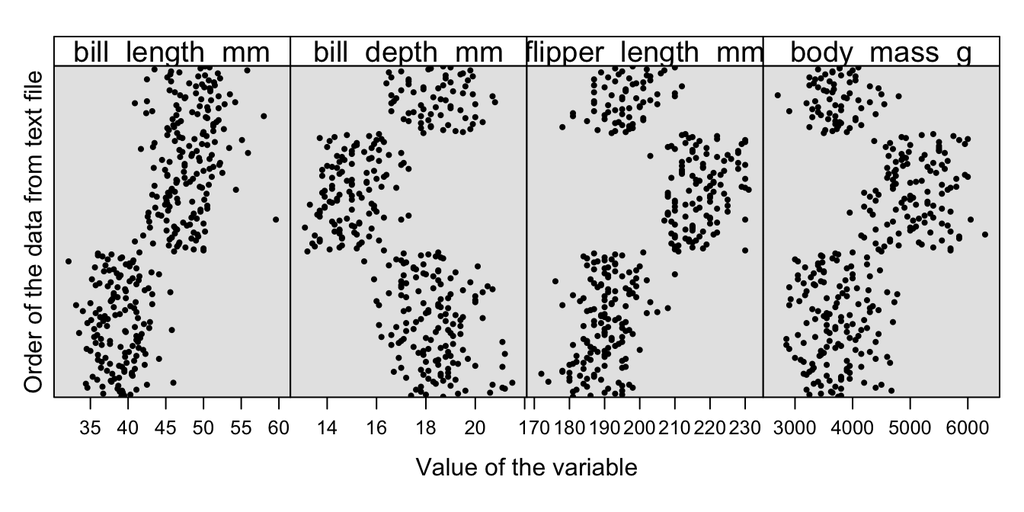

### Collinearity

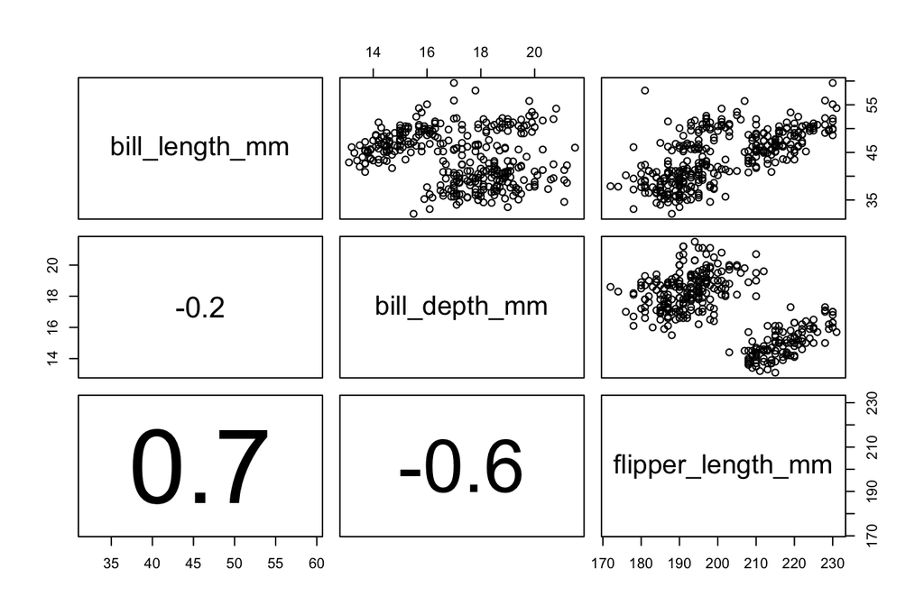

```r
#Collinearity
MyVar <- c("bill_length_mm", "bill_depth_mm", "flipper_length_mm")

panel.cor <- function(x, y, digits=1, prefix="", cex.cor = 6)
{
  usr <- par("usr"); on.exit(par(usr))
  par(usr = c(0, 1, 0, 1))
  r1=cor(x,y,use="pairwise.complete.obs")
  r <- abs(cor(x, y,use="pairwise.complete.obs"))
  txt <- format(c(r1, 0.123456789), digits=digits)[1]
  txt <- paste(prefix, txt, sep="")
  if(missing(cex.cor)) { cex <- 0.9/strwidth(txt) } else {
     cex = cex.cor}
  text(0.5, 0.5, txt, cex = cex * r)
}

pairs(penguins[, MyVar],
      lower.panel = panel.cor)
```

### VIF

```r
#####################################################################
#VIF FUNCTION.
#To use:  corvif(YourDataFile)
corvif <- function(dataz) {
  dataz <- as.data.frame(dataz)

  #vif part
  form    <- formula(paste("fooy ~ ",paste(strsplit(names(dataz)," "),collapse=" + ")))
  dataz   <- data.frame(fooy=1 + rnorm(nrow(dataz)) ,dataz)
  lm_mod  <- lm(form,dataz)

  cat("\n\nVariance inflation factors\n\n")
  print(myvif(lm_mod))
}


#Support function for corvif. Will not be called by the user
myvif <- function(mod) {
  v <- vcov(mod)
  assign <- attributes(model.matrix(mod))$assign
  if (names(coefficients(mod)[1]) == "(Intercept)") {
    v <- v[-1, -1]
    assign <- assign[-1]
  } else warning("No intercept: vifs may not be sensible.")
  terms <- labels(terms(mod))
  n.terms <- length(terms)
  if (n.terms < 2) stop("The model contains fewer than 2 terms")
  if (length(assign) > dim(v)[1] ) {
    diag(tmp_cor)<-0
    if (any(tmp_cor==1.0)){
      return("Sample size is too small, 100% collinearity is present")
    } else {
      return("Sample size is too small")
    }
  }
  R <- cov2cor(v)
  detR <- det(R)
  result <- matrix(0, n.terms, 3)
  rownames(result) <- terms
  colnames(result) <- c("GVIF", "Df", "GVIF^(1/2Df)")
  for (term in 1:n.terms) {
    subs <- which(assign == term)
    result[term, 1] <- det(as.matrix(R[subs, subs])) * det(as.matrix(R[-subs, -subs])) / detR
    result[term, 2] <- length(subs)
  }
  if (all(result[, 2] == 1)) {
    result <- data.frame(GVIF=result[, 1])
  } else {
    result[, 3] <- result[, 1]^(1/(2 * result[, 2]))
  }
  invisible(result)
}
#END VIF FUNCTIONS
```

```
##
##
## Variance inflation factors
##
##                       GVIF
## bill_length_mm    1.850958
## bill_depth_mm     1.593411
## flipper_length_mm 2.633327
```

## Fitting the model: Poisson GLM

We apply the following Poisson GLM:

$$Bodymass_{i} \sim
Poisson(\mu_{i})$$
$$E(Bodymass_{i}) =
var(Bodymass_{i}) = \mu_{i}$$
$$\log(\mu_{i})=\eta_{i}$$

$$\eta_{i} = \beta_{1} + \beta_{2}\times
billlength + \beta_{3}\times billdepth + \beta_{4}\times
flipperlength,$$
The body mass (g), denoted by $Bodymass_{i}$, is assumed to follow a Poisson distribution with mean and variance $\mu_i$. The log link function is used

Before applying the model, we standarize the covariates. **standarize** $\sim$ for each covariate the mean is subtracted from the individual values, and the values are divided by its standard deviation.

```r
penguins$bill_length_mm.std      <- as.numeric(scale(penguins$bill_length_mm))
penguins$bill_depth_mm.std  <- as.numeric(scale(penguins$bill_depth_mm))
penguins$flipper_length_mm.std <- as.numeric(scale(penguins$flipper_length_mm))
```

The following code fits the model using maximum likelihood estimation and presents the estimated parameters, standard errors, z-values, and *p*-values.

```r
M1 <- glm(body_mass_g ~ bill_length_mm.std +
                    bill_depth_mm.std + flipper_length_mm.std,
          family = "poisson",
          data = penguins)
```

```r
print(summary(M1), digits=3, signif.stars = FALSE)
```

```
##
## Call:
## glm(formula = body_mass_g ~ bill_length_mm.std + bill_depth_mm.std +
##     flipper_length_mm.std, family = "poisson", data = penguins)
##
## Coefficients:
##                       Estimate Std. Error z value Pr(>|z|)
## (Intercept)           8.330987   0.000856 9731.39  < 2e-16
## bill_length_mm.std    0.004933   0.001187    4.16  3.2e-05
## bill_depth_mm.std     0.009089   0.001065    8.54  < 2e-16
## flipper_length_mm.std 0.165190   0.001383  119.48  < 2e-16
##
## (Dispersion parameter for poisson family taken to be 1)
##
##     Null deviance: 50282  on 332  degrees of freedom
## Residual deviance: 11834  on 329  degrees of freedom
## AIC: 15226
##
## Number of Fisher Scoring iterations: 4
```

We apply the following Poisson GLM:

$$Bodymass_{i} \sim
Poisson(\mu_{i})$$

$$E(Bodymass_{i}) = var(Bodymass_{i}) =
\mu_{i}$$

$$\log(\mu_{i}) = 8.33 + 0.005\times
billlength_i + 0.01\times billdepth_i + 0.16\times flipperlength_i$$

Note that this covariates are estandarised. We find positive effect of all covariates.

```r
par(mfrow = c(1,3), mar = c(5,5,2,2))
plot(x=penguins$bill_length_mm.std , y = penguins$body_mass_g,
     xlab = "Standardized bill length",
     ylab = "Body mass",
     ylim = c(3500, 4500),
     cex.lab = 1,
     pch = 16, type = "n")

range(penguins$bill_length_mm.std)
```

```
## [1] -2.174715  2.853932
```

```r
MyData <- data.frame(bill_length_mm.std = seq(-1.1, 4, length = 25),
                     bill_depth_mm.std   = 0,
                     flipper_length_mm.std = 0)
P1 <- predict(M1, newdata = MyData, type = "link", se = TRUE)
lines(x = MyData$bill_length_mm.std, y = exp(P1$fit), lwd = 3)
lines(x = MyData$bill_length_mm.std, y = exp(P1$fit + 2*P1$se.fit), lwd = 3, lty = 2)
lines(x = MyData$bill_length_mm.std, y = exp(P1$fit - 2*P1$se.fit), lwd = 3, lty = 2)


plot(x=penguins$bill_depth_mm.std  , y = penguins$body_mass_g,
     xlab = "Standardized bill depth",
     ylab = "Body mass",
     ylim = c(3500, 4500),
     cex.lab = 1,
     pch = 16, type = "n")

range(penguins$bill_depth_mm.std )
```

```
## [1] -2.064184  2.201431
```

```r
MyData <- data.frame(bill_length_mm.std = 0,
                     bill_depth_mm.std   = seq(-3, 1.5, length = 25),
                     flipper_length_mm.std = 0)
P1 <- predict(M1, newdata = MyData, type = "link", se = TRUE)
lines(x = MyData$bill_depth_mm.std , y = exp(P1$fit), lwd = 3)
lines(x = MyData$bill_depth_mm.std , y = exp(P1$fit + 2*P1$se.fit), lwd = 3, lty = 2)
lines(x = MyData$bill_depth_mm.std , y = exp(P1$fit - 2*P1$se.fit), lwd = 3, lty = 2)



plot(x=penguins$flipper_length_mm.std , y = penguins$body_mass_g,
     xlab = "Standardized flipper length",
     ylab = "Body mass",
     ylim = c(2500, 5000),
     cex.lab = 1,
     pch = 16, type = "n")

range(penguins$flipper_length_mm.std)
```

```
## [1] -2.066742  2.142804
```

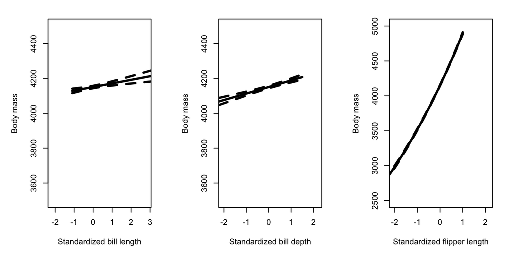

```r
MyData <- data.frame(bill_length_mm.std = 0,
                     bill_depth_mm.std   = 0,
                     flipper_length_mm.std = seq(-4, 1, length = 25))
P1 <- predict(M1, newdata = MyData, type = "link", se = TRUE)
lines(x = MyData$flipper_length_mm.std, y = exp(P1$fit), lwd = 3)
lines(x = MyData$flipper_length_mm.std, y = exp(P1$fit + 2*P1$se.fit), lwd = 3, lty = 2)
lines(x = MyData$flipper_length_mm.std, y = exp(P1$fit - 2*P1$se.fit), lwd = 3, lty = 2)
```

Predicted body mass plotted versus one covariate. In each panel one covariate varies and the other to are set to their mean value (which is 0, as they are standarized). Dotted lines show 95% confidence intervals for the mean.

Now we can extract Pearson residuals and assesses whether there is overdispersion (or underdispersion)

```r
E1 <- resid(M1, type = "pearson")
sum(E1^2) / (nrow(penguins) - length(coef(M1)))
```

```
## [1] 36.2135
```

The dispersion parameter is considerably greater than 1; hence there is overdispersion. There maybe various reasons for overdispersion: a missing covariate, outliers, zero-inflaction, correlation, wrong link function, or the wrong distribution (such as Poisson instead of negative binomial).

A detailed model validation should be applied to find the source of overdispersion, so that the model can be improved.

### Model validation - Pearson residuals

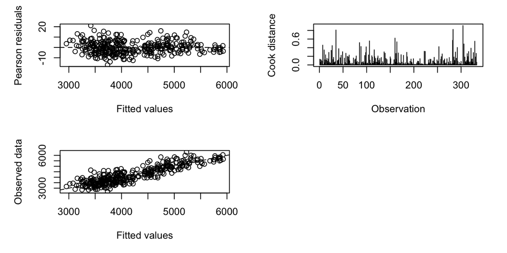

```r
F1 <- fitted(M1, type = "response")

par(mfrow = c(2,2), mar = c(5,5,2,2))
plot(x = F1, y = E1, xlab = "Fitted values",
     ylab = "Pearson residuals", cex.lab = 1)
abline(h=0, lty = 2)

plot(cooks.distance(M1), type = "h",
     xlab = "Observation", ylab = "Cook distance",
     cex.lab =  1)

plot(y = penguins$body_mass_g, x = F1,
      xlab = "Fitted values",
      ylab = "Observed data",
      cex.lab = 1, )
 abline(coef=c(0, 1), lty = 2)
```

- Panel A: there are some observations with large Pearson residuals
- Panel B: Cook’c distance values , wich is a LOO measure of influence. There are at least 5 observations that have large influence. If there is one or two observations with large influence we can remove them, but in this case there are too many to do it.
- Panel C: shows fitted values v.s. observed data. One hopes to see all the points following the dotted line.

### Zero-inflation

```r
sum(penguins$body_mass_g==0) / nrow(penguins)
```

```
## [1] 0
```

The model validation did not suggest ways to improve the model. There is no 0 values, so the overdispersion is not caused by zero-inflation. If the overdispersion in a Poisson GLM is due to a large variation, the **negative binomial GLM** is a candidate model.

## Fitting the model: NEgative Binomial GLM

$$Bodymass_{i} \sim
NB(\mu_{i},k)$$

$$E(Bodymass_{i}) = \mu_{i}$$

$$var(Bodymass_{i}) =
\mu_{i}\frac{\mu_{i}^{2}}{k}$$

$$\log(\mu_{i}) = \beta_{1} +
\beta_{2}\times billlength + \beta_{3}\times billdepth + \beta_{4}\times
flipperlength$$

```
##
## Call:
## glm.nb(formula = body_mass_g ~ bill_length_mm.std + bill_depth_mm.std +
##     flipper_length_mm.std, data = penguins, init.theta = 115.8185676,
##     link = log)
##
## Coefficients:
##                       Estimate Std. Error  z value Pr(>|z|)
## (Intercept)           8.331120   0.005163 1613.479   <2e-16 ***
## bill_length_mm.std    0.005263   0.007040    0.747   0.4548
## bill_depth_mm.std     0.011616   0.006526    1.780   0.0751 .
## flipper_length_mm.std 0.164619   0.008393   19.613   <2e-16 ***
## ---
## Signif. codes:  0 '***' 0.001 '**' 0.01 '*' 0.05 '.' 0.1 ' ' 1
##
## (Dispersion parameter for Negative Binomial(115.8186) family taken to be 1)
##
##     Null deviance: 1339.83  on 332  degrees of freedom
## Residual deviance:  333.88  on 329  degrees of freedom
## AIC: 4928.9
##
## Number of Fisher Scoring iterations: 1
##
##
##               Theta:  115.82
##           Std. Err.:  9.23
##
##  2 x log-likelihood:  -4918.867
```

`Theta` in the numerical output is the *k* from the variance function, and is estimated as 115.82. The explained variation is (1339.83-333.88)/1339.83 = 75% and is similar to that obtained by the Poisson GLM.

### Assess overdispersion:

```r
E2 <- resid(M2, type = "pearson")
p <- length(coef(M2)) + 1
sum(E2^2) / (nrow(penguins) - p)
```

```
## [1] 1.025822
```

There is a small amount of overdispersion

```
## Single term deletions
##
## Model:
## body_mass_g ~ bill_length_mm.std + bill_depth_mm.std + flipper_length_mm.std
##                       Df Deviance    AIC    LRT Pr(>Chi)
## <none>                     333.88 4926.9
## bill_length_mm.std     1   334.43 4925.4   0.55  0.45951
## bill_depth_mm.std      1   337.05 4928.0   3.17  0.07483 .
## flipper_length_mm.std  1   715.84 5306.8 381.96  < 2e-16 ***
## ---
## Signif. codes:  0 '***' 0.001 '**' 0.01 '*' 0.05 '.' 0.1 ' ' 1
```

The estimated negative binomial GLM with the standarized covariates can be written as:

$$Bodymass_{i} \sim
NB(\mu_{i},115.82)$$

$$E(Bodymass_{i}) = \mu_{i}$$

$$var(Bodymass_{i}) =
\mu_{i}\frac{\mu_{i}^{2}}{115.82}$$

$$\log(\mu_{i}) = 8.33 + 0.005\times
billlength_i + 0.01\times billdepth_i + 0.16\times flipperlength_i
,$$

```r
M2A <- glm.nb(body_mass_g ~ bill_length_mm.std + flipper_length_mm.std,
             data = penguins)
summary(M2A)
```

```
##
## Call:
## glm.nb(formula = body_mass_g ~ bill_length_mm.std + flipper_length_mm.std,
##     data = penguins, init.theta = 114.7072086, link = log)
##
## Coefficients:
##                       Estimate Std. Error  z value Pr(>|z|)
## (Intercept)           8.331162   0.005188 1605.941   <2e-16 ***
## bill_length_mm.std    0.008096   0.006865    1.179    0.238
## flipper_length_mm.std 0.155945   0.006859   22.735   <2e-16 ***
## ---
## Signif. codes:  0 '***' 0.001 '**' 0.01 '*' 0.05 '.' 0.1 ' ' 1
##
## (Dispersion parameter for Negative Binomial(114.7072) family taken to be 1)
##
##     Null deviance: 1327.31  on 332  degrees of freedom
## Residual deviance:  333.91  on 330  degrees of freedom
## AIC: 4930
##
## Number of Fisher Scoring iterations: 1
##
##
##               Theta:  114.71
##           Std. Err.:  9.14
##
##  2 x log-likelihood:  -4922.026
```

```
## Likelihood ratio tests of Negative Binomial Models
##
## Response: body_mass_g
##                                                            Model    theta
## 1                     bill_length_mm.std + flipper_length_mm.std 114.7072
## 2 bill_length_mm.std + bill_depth_mm.std + flipper_length_mm.std 115.8186
##   Resid. df    2 x log-lik.   Test    df LR stat.    Pr(Chi)
## 1       330       -4922.026
## 2       329       -4918.867 1 vs 2     1 3.159174 0.07550139
```

```r
par(mfrow = c(1,3), mar = c(5,5,2,2))
plot(x = penguins$bill_length_mm.std,
     y = penguins$body_mass_g,
     xlab = "Standardized bill length",
     ylab = "Body mass",
     cex.lab = 2,
     pch = 16, type = "n")

range(penguins$bill_length_mm.std)
```

```
## [1] -2.174715  2.853932
```

```r
MyData <- data.frame(bill_length_mm.std = seq(-1.1, 4, length = 25),
                     bill_depth_mm.std  = 0,
                     flipper_length_mm.std = 0)
P1 <- predict(M2, newdata = MyData, type = "link", se = TRUE)
lines(x = MyData$bill_length_mm.std, y = exp(P1$fit), lwd = 3)
lines(x = MyData$bill_length_mm.std, y = exp(P1$fit + 2*P1$se.fit), lwd = 3, lty = 2)
lines(x = MyData$bill_length_mm.std, y = exp(P1$fit - 2*P1$se.fit), lwd = 3, lty = 2)


plot(x=penguins$bill_depth_mm.std , y = penguins$body_mass_g,
     xlab = "Standardized bill depth",
     ylab = "Body mass",
     cex.lab = 2,
     pch = 16, type = "n")

range(penguins$bill_depth_mm.std)
```

```
## [1] -2.064184  2.201431
```

```r
MyData <- data.frame(bill_length_mm.std = 0,
                     bill_depth_mm.std  = seq(-3, 1.5, length = 25),
                     flipper_length_mm.std = 0)
P1 <- predict(M2, newdata = MyData, type = "link", se = TRUE)
lines(x = MyData$bill_depth_mm.std, y = exp(P1$fit), lwd = 3)
lines(x = MyData$bill_depth_mm.std, y = exp(P1$fit + 2*P1$se.fit), lwd = 3, lty = 2)
lines(x = MyData$bill_depth_mm.std, y = exp(P1$fit - 2*P1$se.fit), lwd = 3, lty = 2)



plot(x=penguins$flipper_length_mm.std , y = penguins$body_mass_g,
     xlab = "Standardized flipper length",
     ylab = "Body mass",
     cex.lab = 2,
     pch = 16, type = "n")

range(penguins$flipper_length_mm.std)
```

```
## [1] -2.066742  2.142804
```

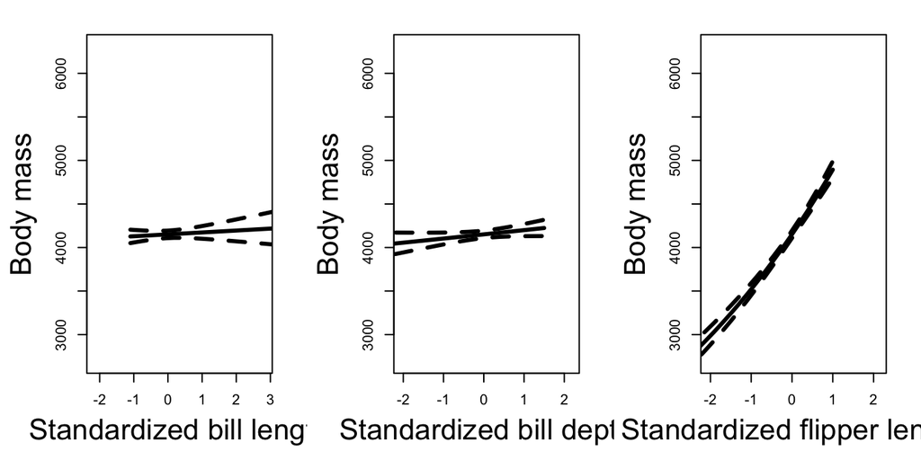

```r
MyData <- data.frame(bill_length_mm.std = 0,
                     bill_depth_mm.std  = 0,
                     flipper_length_mm.std = seq(-4, 1, length = 25))
P1 <- predict(M2, newdata = MyData, type = "link", se = TRUE)
lines(x = MyData$flipper_length_mm.std, y = exp(P1$fit), lwd = 3)
lines(x = MyData$flipper_length_mm.std, y = exp(P1$fit + 2*P1$se.fit), lwd = 3, lty = 2)
lines(x = MyData$flipper_length_mm.std, y = exp(P1$fit - 2*P1$se.fit), lwd = 3, lty = 2)
```